# VAR Predictability Benchmark

Results

Author

Affiliation

Björn S. Siepe

University of Marburg

Published

October 12, 2026

# 1 Preparation

# 2 Descriptives

## 2.1 Sample overview

`n_total_person` counts rows present in the raw data and may underestimate the true number of scheduled beeps if absent responses were never recorded (implicit missingness). It is used as a proxy for series length, not as a compliance measure.

```r
person_n <- combined |>
  distinct(dataset_id, id, n_valid_person, n_total_person) |>
  summarise(valid_median = median(n_valid_person), valid_min = min(n_valid_person),
            valid_max = max(n_valid_person), rows_median = median(n_total_person),
            .by = dataset_id)

dataset_meta |>
  left_join(person_n, by = "dataset_id") |>
  arrange(first_author, year) |>
  mutate(dataset = paste0(first_author, " (", year, ")"),
         valid = sprintf("%g [%g, %g]", valid_median, valid_min, valid_max)) |>
  select(dataset, n_beeps_per_day, n_persons_kept, n_persons_excluded, n_items,
         valid, rows_median) |>
  knitr::kable(col.names = c("Dataset", "Beeps per day", "Persons", "Excluded", "Items",
                             "Valid obs. per person, median [range]", "Rows per person, median"))
```

Table 1: Sample overview per dataset. Valid observations are timepoints with complete responses and a usable lag.

| Dataset | Beeps per day | Persons | Excluded | Items | Valid obs. per person, median [range] | Rows per person, median |
| --- | --- | --- | --- | --- | --- | --- |
| Bosley (2019) | 4 | 25 | 71 | 3 | 22 [20, 34] | 34.0 |
| Contreras (2020) | 10 | 12 | 11 | 5 | 25.5 [20, 35] | 41.0 |
| Drukker (2020) | 10 | 17 | 7 | 8 | 35 [23, 89] | 49.0 |
| Fisher (2017) | 4 | 40 | 0 | 21 | 80.5 [61, 112] | 128.5 |
| Fried (2021) | 4 | 50 | 29 | 14 | 40 [23, 42] | 56.0 |
| Geschwind (2013) | 10 | 122 | 8 | 6 | 82 [20, 106] | 220.0 |
| Grommisch (2020) | 9 | 179 | 0 | 4 | 149 [51, 181] | 172.0 |
| Kullar (2023) | 5 | 98 | 7 | 8 | 52 [27, 56] | 70.0 |
| Kuppens (2016) | 10 | 93 | 2 | 6 | 60 [39, 72] | 66.0 |
| Marian (2022) | 3 | 35 | 110 | 13 | 40 [24, 42] | 63.0 |
| Merolla (2022) | 6 | 53 | 67 | 2 | 26 [20, 46] | 60.0 |
| Nestler (2022) | 1 | 84 | 1 | 6 | 76.5 [43, 81] | 79.5 |
| Neubauer (2020) | 1 | 70 | 492 | 5 | 20 [20, 20] | 21.0 |
| Pavani (2017) | 5 | 70 | 8 | 7 | 40.5 [25, 55] | 70.0 |
| Reeves (2020) | 4 | 20 | 0 | 17 | 80 [67, 92] | 124.0 |
| Rowland (2020) | 6 | 125 | 0 | 8 | 144 [48, 188] | 240.0 |
| Wang (2024) | 7 | 67 | 5 | 4 | 92 [31, 105] | 147.0 |
| Westhoff (2024) | 5 | 113 | 0 | 6 | 78 [58, 84] | 105.0 |
| Wright (2019) | 1 | 94 | 0 | 5 | 90 [54, 100] | 94.0 |
| van Woerkom (2022) | 10 | 70 | 103 | 15 | 32 [20, 44] | 50.0 |

## 2.2 Exclusions

```r
dataset_meta |>
  arrange(first_author, year) |>
  mutate(dataset = paste0(first_author, " (", year, ")")) |>
  select(dataset, n_persons_kept, n_excluded_low_obs, n_excluded_zero_var) |>
  knitr::kable(col.names = c("Dataset", "Included", "Excluded: too few valid obs.",
                             "Excluded: zero variance"))
```

Table 2: Persons included and excluded per dataset, by reason.

| Dataset | Included | Excluded: too few valid obs. | Excluded: zero variance |
| --- | --- | --- | --- |
| Bosley (2019) | 25 | 71 | 0 |
| Contreras (2020) | 12 | 10 | 1 |
| Drukker (2020) | 17 | 2 | 5 |
| Fisher (2017) | 40 | 0 | 0 |
| Fried (2021) | 50 | 4 | 25 |
| Geschwind (2013) | 122 | 2 | 6 |
| Grommisch (2020) | 179 | 0 | 0 |
| Kullar (2023) | 98 | 0 | 7 |
| Kuppens (2016) | 93 | 0 | 2 |
| Marian (2022) | 35 | 3 | 107 |
| Merolla (2022) | 53 | 66 | 1 |
| Nestler (2022) | 84 | 1 | 0 |
| Neubauer (2020) | 70 | 490 | 2 |
| Pavani (2017) | 70 | 1 | 7 |
| Reeves (2020) | 20 | 0 | 0 |
| Rowland (2020) | 125 | 0 | 0 |
| Wang (2024) | 67 | 1 | 4 |
| Westhoff (2024) | 113 | 0 | 0 |
| Wright (2019) | 94 | 0 | 0 |
| van Woerkom (2022) | 70 | 55 | 48 |

```r
rel_mse_drops |>
  filter(set == "oos") |>
  left_join(select(dataset_meta, dataset_id, first_author, year), by = "dataset_id") |>
  mutate(dataset = paste0(first_author, " (", year, ")"),
         model = factor(model, levels = model_order, labels = model_labels)) |>
  arrange(model) |>
  pivot_wider(id_cols = c(dataset, reason_na), names_from = model, values_from = n,
              values_fill = 0) |>
  arrange(dataset, reason_na) |>
  rename(Dataset = dataset, Reason = reason_na) |>
  knitr::kable()
```

Table 3: Persons without a defined OOS relative MSE, per dataset, reason and model. zero_model: the model predicts an item exactly. zero_reference: the mean model predicts an item exactly. missing: an item has no scored predictions. Persons are excluded only for the affected model.

| Dataset | Reason | Mean | LOCF | Trend | RI | AR | VAR | mlAR | mlVAR |
| --- | --- | --- | --- | --- | --- | --- | --- | --- | --- |
| Contreras (2020) | zero_model | 0 | 4 | 0 | 0 | 0 | 0 | 0 | 0 |
| Drukker (2020) | zero_model | 0 | 7 | 0 | 0 | 1 | 0 | 0 | 0 |
| Fisher (2017) | zero_model | 0 | 2 | 0 | 0 | 0 | 0 | 0 | 0 |
| Fried (2021) | zero_model | 0 | 28 | 0 | 0 | 1 | 1 | 0 | 0 |
| Geschwind (2013) | zero_model | 0 | 57 | 0 | 0 | 0 | 0 | 0 | 0 |
| Grommisch (2020) | zero_model | 0 | 15 | 0 | 0 | 0 | 0 | 0 | 0 |
| Kullar (2023) | zero_model | 0 | 48 | 0 | 0 | 0 | 0 | 0 | 0 |
| Kuppens (2016) | zero_model | 0 | 10 | 0 | 0 | 0 | 0 | 0 | 0 |
| Marian (2022) | zero_model | 0 | 25 | 0 | 0 | 2 | 3 | 0 | 0 |
| Merolla (2022) | zero_model | 0 | 1 | 0 | 0 | 0 | 0 | 0 | 0 |
| Nestler (2022) | zero_model | 0 | 11 | 0 | 0 | 0 | 0 | 0 | 0 |
| Neubauer (2020) | zero_model | 0 | 6 | 0 | 0 | 0 | 0 | 0 | 0 |
| Pavani (2017) | zero_model | 0 | 25 | 0 | 0 | 2 | 0 | 0 | 0 |
| Reeves (2020) | zero_model | 0 | 3 | 0 | 0 | 0 | 0 | 0 | 0 |
| Rowland (2020) | zero_model | 0 | 8 | 0 | 0 | 0 | 0 | 0 | 0 |
| Wang (2024) | zero_model | 0 | 13 | 0 | 0 | 0 | 0 | 0 | 0 |
| Westhoff (2024) | zero_model | 0 | 5 | 0 | 0 | 0 | 0 | 0 | 0 |
| Wright (2019) | zero_model | 0 | 12 | 0 | 0 | 0 | 0 | 0 | 0 |
| van Woerkom (2022) | zero_model | 0 | 20 | 0 | 0 | 3 | 1 | 0 | 0 |
| van Woerkom (2022) | zero_reference | 1 | 1 | 1 | 1 | 1 | 1 | 1 | 1 |

## 2.3 Non-Convergence

```r
ols_models <- c("ar", "var")
ml_models <- c("ri", "ml_ar", "ml_var")

# share of affected fits for one issue type, one column per model
issue_share <- function(models, issue, labels, prefix) {
  fit_issues |>
    filter(model %in% models, type == issue) |>
    mutate(share = sprintf("%.0f%%", 100 * n / n_fits),
           model = paste(prefix, factor(model, levels = models, labels = labels))) |>
    select(dataset_id, model, share) |>
    pivot_wider(names_from = model, values_from = share)
}

rank_deficient <- issue_share(ols_models, "rank_deficient", c("AR", "VAR"), "Rank-deficient:")
singular <- issue_share(ml_models, "singular", c("RI", "mlAR", "mlVAR"), "Singular:")

other_issues <- fit_issues |>
  summarise(`Convergence warnings` = sum(n[type == "convergence"]),
            `Other warnings` = sum(n[type == "other"]), .by = dataset_id)

failed <- dataset_meta |>
  mutate(failed = vapply(model_failures, function(f) {
    paste(model_labels[match(names(f)[f], model_order)], collapse = ", ")
  }, character(1))) |>
  select(dataset_id, first_author, year, failed, ml_var_uncorrelated)

failed |>
  left_join(rank_deficient, by = "dataset_id") |>
  left_join(singular, by = "dataset_id") |>
  left_join(other_issues, by = "dataset_id") |>
  arrange(first_author, year) |>
  mutate(Dataset = paste0(first_author, " (", year, ")"),
         `Failed models` = failed,
         `mlVAR uncorrelated RE` = if_else(ml_var_uncorrelated, "yes", "no")) |>
  select(Dataset, starts_with("Rank-deficient"), starts_with("Singular"),
         `Convergence warnings`, `Other warnings`, `Failed models`, `mlVAR uncorrelated RE`) |>
  knitr::kable()
```

Table 4: Estimation issues per dataset. Rank-deficient fits are the share of person-level OLS fits with aliased coefficients (set to 0). Singular fits are the share of lmer fits (one per item and fit step). Convergence and other warnings are counts of warnings.

| Dataset | Rank-deficient: AR | Rank-deficient: VAR | Singular: RI | Singular: mlAR | Singular: mlVAR | Convergence warnings | Other warnings | Failed models | mlVAR uncorrelated RE |
| --- | --- | --- | --- | --- | --- | --- | --- | --- | --- |
| Bosley (2019) | 0% | 0% | 0% | 3% | 64% | 0 | 0 |  | no |
| Contreras (2020) | 8% | 8% | 0% | 40% | 95% | 0 | 0 |  | no |
| Drukker (2020) | 3% | 3% | 0% | 0% | 91% | 1 | 0 |  | no |
| Fisher (2017) | 0% | 0% | 0% | 0% | 100% | 2 | 0 |  | yes |
| Fried (2021) | 9% | 17% | 0% | 0% | 100% | 0 | 0 |  | yes |
| Geschwind (2013) | 0% | 0% | 0% | 2% | 62% | 1 | 0 |  | no |
| Grommisch (2020) | 0% | 0% | 0% | 0% | 0% | 0 | 0 |  | no |
| Kullar (2023) | 3% | 3% | 0% | 0% | 81% | 1 | 0 |  | no |
| Kuppens (2016) | 0% | 0% | 0% | 0% | 80% | 2 | 0 |  | no |
| Marian (2022) | 16% | 23% | 0% | 0% | 100% | 0 | 0 |  | yes |
| Merolla (2022) | 0% | 0% | 0% | 0% | 27% | 0 | 0 |  | no |
| Nestler (2022) | 0% | 0% | 83% | 83% | 98% | 0 | 0 |  | no |
| Neubauer (2020) | 2% | 2% | 0% | 5% | 64% | 0 | 0 |  | no |
| Pavani (2017) | 4% | 4% | 0% | 0% | 69% | 0 | 0 |  | no |
| Reeves (2020) | 0% | 0% | 0% | 1% | 100% | 1 | 0 |  | yes |
| Rowland (2020) | 0% | 0% | 0% | 0% | 66% | 0 | 0 |  | no |
| Wang (2024) | 0% | 0% | 0% | 0% | 2% | 0 | 0 |  | no |
| Westhoff (2024) | 0% | 0% | 0% | 0% | 50% | 2 | 0 |  | no |
| Wright (2019) | 0% | 0% | 0% | 0% | 20% | 0 | 0 |  | no |
| van Woerkom (2022) | 11% | 17% | 0% | 5% | 100% | 0 | 0 |  | yes |

## 2.4 Computation Times

```r
# fits per person (person-level models) and per item and step (lmer models) are not comparable
# units, so times are compared per dataset rather than per fit
fit_times |>
  summarise(total_min = sum(cpu_sec) / 60, median_sec = median(cpu_sec),
            max_sec = max(cpu_sec), .by = model) |>
  mutate(model = factor(model, levels = model_order, labels = model_labels)) |>
  arrange(model) |>
  knitr::kable(digits = 1, col.names = c("Model", "Total CPU time (min)",
                                         "Median per dataset (s)", "Slowest dataset (s)"))
```

Table 5: CPU time per model for the full rolling-origin evaluation, including all refits.

| Model | Total CPU time (min) | Median per dataset (s) | Slowest dataset (s) |
| --- | --- | --- | --- |
| Mean | 0.3 | 0.8 | 1.3 |
| LOCF | 0.1 | 0.4 | 0.8 |
| Trend | 0.2 | 0.5 | 1.2 |
| RI | 13.7 | 39.0 | 79.7 |
| AR | 0.2 | 0.6 | 1.2 |
| VAR | 0.1 | 0.3 | 0.8 |
| mlAR | 21.5 | 38.7 | 389.0 |
| mlVAR | 158.0 | 320.1 | 2599.4 |

```r
# times are only comparable between models run on the same machine
unique(fit_times$cpu)
```

```
[1] "AMD Ryzen Threadripper 3970X 32-Core Processor"
```

## 2.5 Extreme Relative Errors

```r
# 20 times higher or lower than the mean model
extreme_cut <- log(20)

combined |>
  filter(set == "oos", model != "mean", is.finite(rel_mse), abs(log(rel_mse)) > extreme_cut) |>
  mutate(direction = if_else(rel_mse > 1, "higher", "lower"),
         model = factor(model, levels = model_order, labels = model_labels),
         dataset = paste0(first_author, " (", year, ")")) |>
  count(dataset, model, direction) |>
  arrange(desc(n)) |>
  knitr::kable(col.names = c("Dataset", "Model", "Error vs. mean model", "Persons"))
```

Table 7: Persons whose OOS MSE is more than 20 times higher or lower than that of the mean model, per dataset and model.

| Dataset | Model | Error vs. mean model | Persons |
| --- | --- | --- | --- |
| van Woerkom (2022) | VAR | higher | 10 |
| Marian (2022) | VAR | higher | 1 |
| Rowland (2020) | AR | lower | 1 |
| Rowland (2020) | VAR | lower | 1 |
| Rowland (2020) | mlAR | lower | 1 |

```r
combined |>
  filter(set == "oos", model == "var", is.finite(rel_mse)) |>
  left_join(select(features$person, dataset_id, id, obs_per_var_eq_par),
            by = c("dataset_id", "id")) |>
  mutate(group = if_else(log(rel_mse) > extreme_cut, "Extreme", "Other")) |>
  summarise(persons = n(), median_obs = median(obs_per_var_eq_par),
            min_obs = min(obs_per_var_eq_par), .by = group) |>
  knitr::kable(digits = 2, col.names = c("VAR error", "Persons",
                                         "Median obs. per coefficient", "Min obs. per coefficient"))
```

Table 8: Training observations per VAR coefficient (first fold) for persons with extremely high VAR error and all other persons.

| VAR error | Persons | Median obs. per coefficient | Min obs. per coefficient |
| --- | --- | --- | --- |
| Other | 1420 | 8.33 | 0.87 |
| Extreme | 11 | 0.88 | 0.62 |

```r
features$oos |>
  filter(model %in% c("ar", "var")) |>
  summarise(share_outside = mean(yhat < -0.5 | yhat > 1.5), max_abs = max(abs(yhat)),
            .by = c(dataset_id, model)) |>
  filter(share_outside > 0) |>
  left_join(select(dataset_meta, dataset_id, first_author, year), by = "dataset_id") |>
  mutate(dataset = paste0(first_author, " (", year, ")"),
         model = factor(model, levels = model_order, labels = model_labels),
         share_outside = sprintf("%.2f%%", 100 * share_outside)) |>
  arrange(desc(max_abs)) |>
  select(dataset, model, share_outside, max_abs) |>
  knitr::kable(digits = 1, col.names = c("Dataset", "Model", "Share of predictions",
                                         "Largest |prediction|"))
```

Table 9: AR and VAR predictions more than half a scale width outside [0, 1], per dataset. Datasets without such predictions are omitted.

| Dataset | Model | Share of predictions | Largest \|prediction\| |
| --- | --- | --- | --- |
| Marian (2022) | VAR | 1.49% | 127.5 |
| van Woerkom (2022) | VAR | 3.35% | 38.5 |
| Fried (2021) | VAR | 1.09% | 3.8 |
| Westhoff (2024) | VAR | 0.01% | 3.5 |
| Geschwind (2013) | VAR | 0.05% | 2.6 |
| Contreras (2020) | VAR | 0.50% | 2.2 |
| Grommisch (2020) | VAR | 0.01% | 2.2 |
| Kullar (2023) | VAR | 0.13% | 1.9 |
| Rowland (2020) | VAR | 0.05% | 1.8 |
| Wang (2024) | VAR | 0.11% | 1.7 |
| Reeves (2020) | VAR | 0.06% | 1.6 |
| Neubauer (2020) | VAR | 0.03% | 1.4 |
| Fisher (2017) | VAR | 0.04% | 1.4 |
| Pavani (2017) | VAR | 0.02% | 1.3 |

# 3 Predictive accuracy across the complexity ladder

## 3.1 Average RMSE across datasets

We first look at the average RMSE across all datasets for each model.

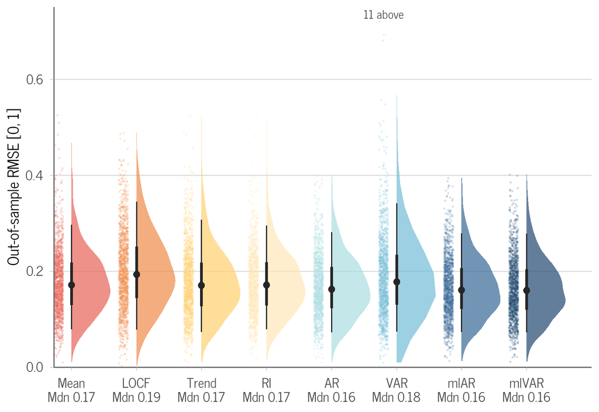

Figure 1: Out-of-sample RMSE by model complexity. Points are persons. Distributions show the median with 50% and 90% intervals.

```r
y_cap <- 0.75

dat_rmse <- dat_oos |>
  # persons are drawn left of the distribution
  mutate(x_points = as.numeric(model) - 0.2)

outliers <- dat_rmse |>
  filter(rmse > y_cap) |>
  count(model, name = "n_out")

message(sprintf("%d observations (%.1f%%) with RMSE > %.2f beyond cap",
                sum(outliers$n_out), 100 * sum(outliers$n_out) / nrow(dat_rmse), y_cap))

# medians in the axis labels, so the panel stays free of text
rmse_medians <- dat_rmse |>
  summarise(median = median(rmse), .by = model)
rmse_axis_labels <- setNames(sprintf("%s\nMdn %.2f", rmse_medians$model, rmse_medians$median),
                             rmse_medians$model)

ggplot(dat_rmse, aes(x = model, y = rmse)) +
  geom_jitter(aes(x = x_points, colour = model), width = 0.07, height = 0, alpha = 0.12,
              size = 0.4) +
  ggdist::stat_halfeye(aes(fill = model), normalize = "groups", scale = 0.6,
                       .width = c(0.5, 0.9), slab_alpha = 0.7, point_size = 2.5,
                       colour = "grey15") +
  # counts beyond the cap sit above the column of person points
  geom_text(data = outliers,
            aes(x = model, y = y_cap, label = paste0(n_out, " above")),
            position = position_nudge(x = -0.2), vjust = 1.3, size = 4, colour = "grey30",
            inherit.aes = FALSE) +
  scale_x_discrete(labels = rmse_axis_labels) +
  scale_fill_manual(values = model_palette, guide = "none") +
  scale_colour_manual(values = model_palette, guide = "none") +
  coord_cartesian(ylim = c(0, y_cap), expand = FALSE) +
  labs(x = NULL, y = "Out-of-sample RMSE [0, 1]") +
  theme_bs()
```

## 3.2 Relative MSE across datasets

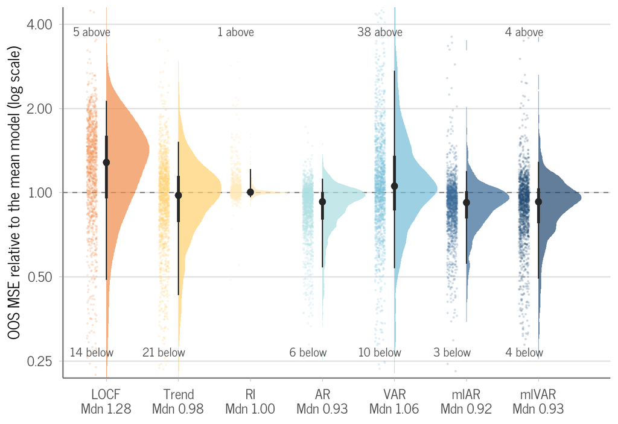

Figure 2: Out-of-sample MSE relative to the mean model by model complexity. Points are persons. Distributions show the median with 50% and 90% intervals. Values below 1 mean lower error than the mean model.

```r
# the mean model is the reference with rel_mse = 1 by construction, so it is not shown
is_reference <- model_order == "mean"

dat_rel <- combined |>
  filter(set == "oos", model != "mean", is.finite(rel_mse)) |>
  mutate(model = factor(model, levels = model_order[!is_reference],
                        labels = model_labels[!is_reference]),
         # persons are drawn left of the distribution
         x_points = as.numeric(model) - 0.2)

# symmetric around 1 on the log axis
rel_lim <- c(0.25, 4)

rel_beyond <- dat_rel |>
  summarise(n_below = sum(rel_mse < rel_lim[1]), n_above = sum(rel_mse > rel_lim[2]),
            .by = model)

# medians in the axis labels, so the panel stays free of text
rel_medians <- dat_rel |>
  summarise(median = median(rel_mse), .by = model)
axis_labels <- setNames(sprintf("%s\nMdn %.2f", rel_medians$model, rel_medians$median),
                        rel_medians$model)

ggplot(dat_rel, aes(x = model, y = rel_mse)) +
  geom_hline(yintercept = 1, colour = "grey50", linetype = "dashed") +
  geom_jitter(aes(x = x_points, colour = model), width = 0.07, height = 0, alpha = 0.12,
              size = 0.4) +
  # each distribution is scaled to its own maximum, otherwise the narrow RI peak flattens all others
  ggdist::stat_halfeye(aes(fill = model), normalize = "groups", scale = 0.6,
                       .width = c(0.5, 0.9), slab_alpha = 0.7, point_size = 2.5,
                       colour = "grey15") +
  # counts beyond the range sit above the column of person points
  geom_text(data = filter(rel_beyond, n_above > 0),
            aes(x = model, y = rel_lim[2], label = paste0(n_above, " above")),
            position = position_nudge(x = -0.2), vjust = 1.3, size = 4, colour = "grey30",
            inherit.aes = FALSE) +
  geom_text(data = filter(rel_beyond, n_below > 0),
            aes(x = model, y = rel_lim[1], label = paste0(n_below, " below")),
            position = position_nudge(x = -0.2), vjust = -0.5, size = 4, colour = "grey30",
            inherit.aes = FALSE) +
  scale_x_discrete(labels = axis_labels) +
  scale_y_log10(breaks = c(0.25, 0.5, 1, 2, 4)) +
  scale_fill_manual(values = model_palette, guide = "none") +
  scale_colour_manual(values = model_palette, guide = "none") +
  coord_cartesian(ylim = rel_lim) +
  labs(x = NULL, y = "OOS MSE relative to the mean model (log scale)") +
  theme_bs()
```

## 3.3 In-sample vs. out-of-sample RMSE

We here compute the in-sample performance by fitting each model on the whole time series, without a test-set split.

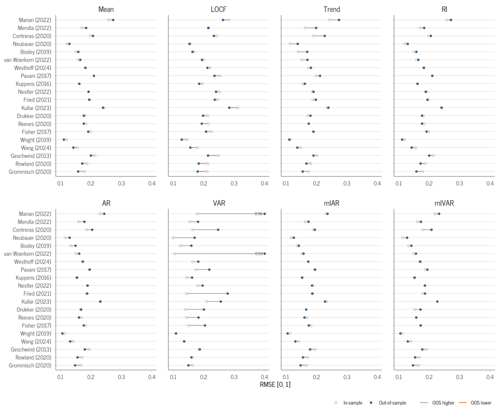

Figure 3: In-sample and OOS RMSE per dataset and model. Points are means across persons. Rows are ordered by the gap of the mean model.

```r
barbell_labels <- dataset_meta |>
  distinct(dataset_id, first_author, year) |>
  mutate(dataset = paste0(first_author, " (", year, ")"),
         dataset = if_else(duplicated(dataset) | duplicated(dataset, fromLast = TRUE),
                           paste0(dataset, " [", dataset_id, "]"), dataset))

is_oos <- combined |>
  filter(set %in% c("in", "oos"), is.finite(rmse), rmse > 0) |>
  select(dataset_id, id, model, set, rmse) |>
  pivot_wider(names_from = set, values_from = rmse) |>
  # persons enter only with both sets, so the dataset gap is paired
  filter(is.finite(`in`), is.finite(oos)) |>
  summarise(is = mean(`in`), oos = mean(oos), .by = c(dataset_id, model)) |>
  left_join(barbell_labels, by = "dataset_id") |>
  mutate(direction = if_else(oos > is, "OOS higher", "OOS lower"),
         model = factor(model, levels = model_order, labels = model_labels))

# largest mean-model gap at the top
row_order <- is_oos |>
  filter(model == "Mean") |>
  arrange(oos - is) |>
  pull(dataset)

# points beyond the cap are drawn at the cap and labelled with their value
x_cap <- 0.4

is_oos <- is_oos |>
  mutate(dataset = factor(dataset, levels = union(row_order, dataset)),
         is_plot = pmin(is, x_cap), oos_plot = pmin(oos, x_cap))

is_oos_points <- is_oos |>
  pivot_longer(c(is, oos), names_to = "set", values_to = "rmse") |>
  mutate(set = factor(set, levels = c("is", "oos"), labels = c("In-sample", "Out-of-sample")),
         rmse_plot = pmin(rmse, x_cap))

ggplot(is_oos, aes(y = dataset)) +
  geom_segment(aes(x = is_plot, xend = oos_plot, colour = direction), linewidth = 0.8) +
  geom_point(data = is_oos_points, aes(x = rmse_plot, fill = set),
             shape = 21, colour = "grey30", size = 1.8, stroke = 0.3) +
  geom_text(data = filter(is_oos_points, rmse > x_cap),
            aes(x = x_cap, label = sprintf("%.2f", rmse)),
            hjust = 1.3, size = 2.5, colour = "grey20") +
  scale_colour_manual(values = c("OOS higher" = "grey70",
                                 "OOS lower" = component_palette[["Cross-dynamics"]]),
                      name = NULL) +
  scale_fill_manual(values = c("In-sample" = "white",
                               "Out-of-sample" = component_palette[["Autoregression"]]),
                    name = NULL) +
  ggh4x::facet_wrap2(~ model, nrow = 2, axes = "all", remove_labels = "y") +
  labs(x = "RMSE [0, 1]", y = NULL) +
  theme_bs(base_size = 11) +
  theme(legend.position = "bottom")
```

## 3.4 Model dominance

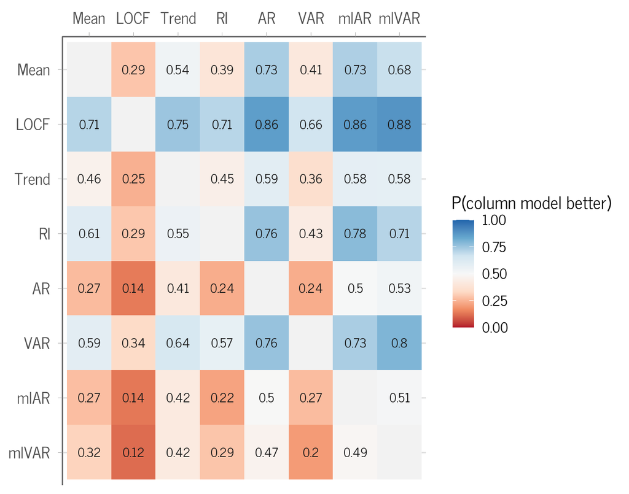

Figure 4: Pairwise model dominance: Proportion of persons where the column model has lower OOS relative MSE than the row model. The Mean row is the share of persons for whom a model beats the mean model. Without a true difference, about 0.5 is expected from noise alone.

```r
model_pairs <- expand.grid(model_a = model_labels, model_b = model_labels,
                           stringsAsFactors = FALSE)

# comparing rel_mse within a person compares geometric-mean MSE over items
dat_wide <- combined |>
  filter(set == "oos", is.finite(rel_mse)) |>
  mutate(model = factor(model, levels = model_order, labels = model_labels)) |>
  select(dataset_id, id, model, rel_mse) |>
  pivot_wider(names_from = model, values_from = rel_mse)

dominance <- model_pairs |>
  rowwise() |>
  mutate(
    prop = if_else(model_a == model_b, NA_real_,
                   mean(dat_wide[[model_a]] < dat_wide[[model_b]], na.rm = TRUE))
  ) |>
  ungroup() |>
  mutate(
    model_a = factor(model_a, levels = model_labels),
    model_b = factor(model_b, levels = rev(model_labels))
  )

ggplot(dominance, aes(x = model_a, y = model_b, fill = prop)) +
  geom_tile() +
  geom_text(aes(label = round(prop, 2)), size = 3.5, colour = "grey10") +
  scale_fill_distiller(palette = "RdBu", limits = c(0, 1), direction = 1,
                       na.value = "grey95",
                       name = "P(column model better)") +
  labs(x = NULL, y = NULL) +
  scale_x_discrete(position = "top") +
  theme_bs() +
  theme(legend.position = "right")
```

## 3.5 Decomposition of predictive gains

Here, we display total model improvement from the mean model to the most complex model (multilevel VAR) and decompose it into three components: autoregression, cross-dynamics, and pooling. We also show two different paths of improvement: first adding cross-dynamics and then pooling, or first pooling and then adding cross-dynamics.

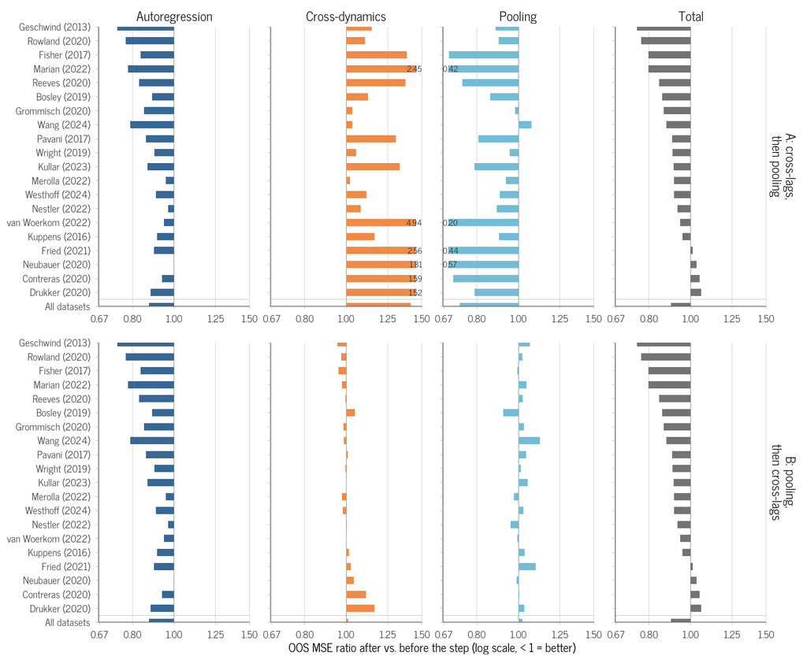

Figure 5: Decomposition of the change in OOS MSE from the mean model to mlVAR, along two paths. Bars are geometric means of the MSE ratio after vs. before each step.

```r
rel_wide <- combined |>
  filter(set == "oos", model %in% decomp_models) |>
  select(dataset_id, first_author, year, id, model, rel_mse) |>
  pivot_wider(names_from = model, values_from = rel_mse)

# persons need all five models for the components to add up
rel_wide <- filter(rel_wide, if_all(all_of(decomp_models), is.finite))

# MSE ratio after vs. before each step. on the log axis, the steps of a path add up to the total.
# values below 1 mean lower error after the step
id_cols <- c("dataset_id", "first_author", "year", "id", "path")
ratios <- bind_rows(
  rel_wide |>
    mutate(path = path_levels[1],
           Autoregression = ar / mean, `Cross-dynamics` = var / ar,
           Pooling = ml_var / var, Total = ml_var / mean),
  rel_wide |>
    mutate(path = path_levels[2],
           Autoregression = ar / mean, `Cross-dynamics` = ml_var / ml_ar,
           Pooling = ml_ar / ar, Total = ml_var / mean)
) |>
  select(all_of(id_cols), all_of(component_levels)) |>
  pivot_longer(all_of(component_levels), names_to = "component", values_to = "ratio")

ratio_ds <- ratios |>
  summarise(ratio = geo_mean(ratio), .by = c(dataset_id, first_author, year, path, component))

# datasets are weighted equally
ratio_all <- ratio_ds |>
  summarise(ratio = geo_mean(ratio), .by = c(path, component)) |>
  mutate(label = "All datasets")

ds_labels <- ratio_ds |>
  distinct(dataset_id, first_author, year) |>
  mutate(label = paste0(first_author, " (", year, ")"),
         label = if_else(duplicated(label) | duplicated(label, fromLast = TRUE),
                         paste0(label, " [", dataset_id, "]"), label))

# largest total improvement at the top
label_order <- ratio_ds |>
  filter(component == "Total", path == path_levels[1]) |>
  left_join(ds_labels, by = c("dataset_id", "first_author", "year")) |>
  arrange(desc(ratio)) |>
  pull(label)

# x-range shared by all panels, symmetric around 1 on the log axis. bars beyond it are cut
# short and labelled with their ratio
x_lim <- c(2 / 3, 1.5)

plot_decomp <- ratio_ds |>
  left_join(ds_labels, by = c("dataset_id", "first_author", "year")) |>
  bind_rows(ratio_all) |>
  mutate(capped = ratio < x_lim[1] | ratio > x_lim[2],
         bar_end = pmin(pmax(ratio, x_lim[1] * 1.03), x_lim[2] / 1.03),
         label = factor(label, levels = c("All datasets", label_order)),
         component = factor(component, levels = component_levels),
         path = factor(path, levels = path_levels))

# bars on a log axis cannot start at 0, so they are drawn from 1 to the ratio
ggplot(plot_decomp, aes(y = label, colour = component)) +
  geom_vline(xintercept = 1, colour = "grey50", linewidth = 0.3) +
  geom_segment(aes(x = 1, xend = bar_end, yend = label), linewidth = 3.5, lineend = "butt") +
  geom_text(data = filter(plot_decomp, capped),
            aes(x = if_else(ratio > 1, x_lim[2], x_lim[1]), label = sprintf("%.2f", ratio),
                hjust = if_else(ratio > 1, 1, 0)),
            size = 2.8, colour = "grey20") +
  geom_hline(yintercept = 1.5, colour = "grey70", linewidth = 0.3) +
  scale_colour_manual(values = component_palette, guide = "none") +
  scale_x_log10(breaks = ratio_breaks) +
  ggh4x::facet_grid2(path ~ component, axes = "all", remove_labels = "y") +
  coord_cartesian(xlim = x_lim, expand = FALSE) +
  labs(x = "OOS MSE ratio after vs. before the step (log scale, < 1 = better)", y = NULL) +
  theme_bs(base_size = 11) +
  theme(panel.grid.major.y = element_blank(),
        panel.grid.major.x = element_line(colour = "#E0E0E0"))
```

## 3.6 Value of pooling by series length

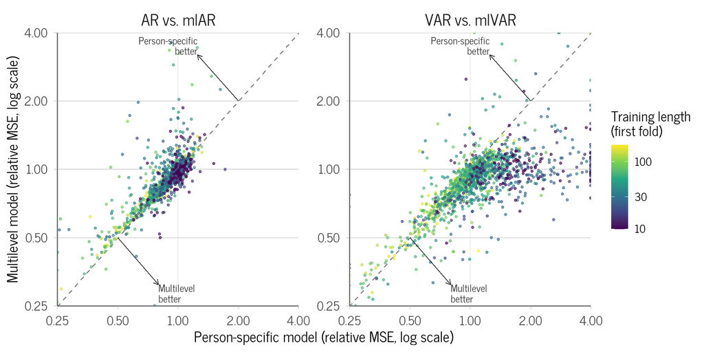

Figure 6: Person-level OOS MSE relative to the mean model: person-specific vs. multilevel model, coloured by training series length. Points below the diagonal: pooling lowered the error. Points outside the range are drawn at its edge.

```r
xy_lim <- c(0.25, 4)

shrinkage <- combined |>
  filter(set == "oos", model %in% c("ar", "ml_ar", "var", "ml_var"), is.finite(rel_mse)) |>
  select(dataset_id, id, model, rel_mse) |>
  pivot_wider(names_from = model, values_from = rel_mse) |>
  pivot_longer(c(ml_ar, ml_var), names_to = "ml_model", values_to = "multilevel") |>
  mutate(person_specific = if_else(ml_model == "ml_ar", ar, var),
         comparison = factor(ml_model, levels = c("ml_ar", "ml_var"),
                             labels = c("AR vs. mlAR", "VAR vs. mlVAR"))) |>
  filter(is.finite(person_specific), is.finite(multilevel)) |>
  left_join(select(features$person, dataset_id, id, n_train_first), by = c("dataset_id", "id")) |>
  # points outside the plotting range are drawn at its edge
  mutate(x_plot = pmin(pmax(person_specific, xy_lim[1]), xy_lim[2]),
         y_plot = pmin(pmax(multilevel, xy_lim[1]), xy_lim[2])) |>
  # short series last, so they are drawn on top
  arrange(desc(n_train_first))

stopifnot(!anyNA(shrinkage$n_train_first))

# arrows from the diagonal into the region where each model has the lower error
better_arrows <- tibble(
  x = c(0.5, 2), y = c(0.5, 2),
  xend = c(0.8, 1.25), yend = c(0.31, 3.2),
  label = c("Multilevel\nbetter", "Person-specific\nbetter"),
  hjust = c(0, 1), vjust = c(1, 0)
)

ggplot(shrinkage, aes(x = x_plot, y = y_plot, colour = n_train_first)) +
  geom_hline(yintercept = 1, colour = "grey85", linewidth = 0.3) +
  geom_vline(xintercept = 1, colour = "grey85", linewidth = 0.3) +
  geom_abline(slope = 1, intercept = 0, colour = "grey50", linetype = "dashed") +
  geom_point(alpha = 0.6, size = 0.9) +
  geom_segment(data = better_arrows, aes(x = x, y = y, xend = xend, yend = yend),
               arrow = arrow(length = unit(0.2, "cm")), colour = "grey20", linewidth = 0.5,
               inherit.aes = FALSE) +
  geom_text(data = better_arrows,
            aes(x = xend, y = yend, label = label, hjust = hjust, vjust = vjust),
            size = 3.5, colour = "grey20", lineheight = 0.9, inherit.aes = FALSE) +
  scale_x_log10(breaks = c(0.25, 0.5, 1, 2, 4)) +
  scale_y_log10(breaks = c(0.25, 0.5, 1, 2, 4)) +
  scale_colour_viridis_c(transform = "log10", name = "Training length\n(first fold)") +
  ggh4x::facet_wrap2(~ comparison, axes = "all") +
  coord_cartesian(xlim = xy_lim, ylim = xy_lim, expand = FALSE) +
  labs(x = "Person-specific model (relative MSE, log scale)",
       y = "Multilevel model (relative MSE, log scale)") +
  theme_bs() +
  theme(legend.position = "right")
```

[figure not shown]

Figure 7: Change in OOS MSE from pooling, by the person’s training series length. The y-axis shows the MSE ratio of the multilevel vs. the person-specific model.

```r
# y-range symmetric around 1 on the log axis
y_lim <- c(0.5, 2)

pooling <- combined |>
  filter(set == "oos", model %in% c("ar", "ml_ar", "var", "ml_var"), is.finite(rel_mse)) |>
  select(dataset_id, id, model, rel_mse) |>
  pivot_wider(names_from = model, values_from = rel_mse) |>
  mutate(`AR → mlAR` = ml_ar / ar, `VAR → mlVAR` = ml_var / var) |>
  select(dataset_id, id, `AR → mlAR`, `VAR → mlVAR`) |>
  pivot_longer(-c(dataset_id, id), names_to = "comparison", values_to = "ratio") |>
  filter(is.finite(ratio)) |>
  left_join(select(features$person, dataset_id, id, n_train_first),
            by = c("dataset_id", "id"))

stopifnot(!anyNA(pooling$n_train_first))

beyond <- pooling |>
  summarise(n_below = sum(ratio < y_lim[1]), n_above = sum(ratio > y_lim[2]),
            .by = comparison) |>
  mutate(label = sprintf("%d above, %d below range", n_above, n_below))

# robust loess downweights persons whose person-specific model breaks down.
# it is fitted on the log axis, so improvements and deteriorations count alike
ggplot(pooling, aes(x = n_train_first, y = ratio)) +
  geom_hline(yintercept = 1, colour = "grey50", linewidth = 0.3) +
  geom_point(alpha = 0.15, size = 0.8, colour = "#2C3E50") +
  geom_smooth(method = "loess", formula = y ~ x, se = TRUE,
              method.args = list(family = "symmetric"),
              colour = component_palette[["Pooling"]], linewidth = 1) +
  # draw one line per dataset to show the within-dataset trend
  # geom_smooth(aes(group = dataset_id), method = "lm", se = FALSE,
  #             colour = scales::alpha("grey50", 0.6), linewidth = 0.5) +
  geom_text(data = beyond, aes(x = -Inf, y = Inf, label = label),
            inherit.aes = FALSE, hjust = -0.05, vjust = 1.5, size = 3, colour = "grey30") +
  scale_x_log10() +
  scale_y_log10(breaks = ratio_breaks) +
  ggh4x::facet_wrap2(~ comparison, axes = "all") +
  coord_cartesian(ylim = y_lim) +
  labs(x = "Training series length (first fold, log scale)",
       y = "OOS MSE ratio (log scale, < 1 = pooling better)") +
  theme_bs()
```

## 3.7 Value of cross-dynamics by data per parameter

[figure not shown]

Figure 8: Change in OOS MSE from adding cross-lagged effects, by the number of training observations per VAR coefficient. The y-axis shows the MSE ratio of the model with vs. without cross-lags.

```r
# y-range symmetric around 1 on the log axis
y_lim_cross <- c(0.5, 2)

cross_dyn <- combined |>
  filter(set == "oos", model %in% c("ar", "var", "ml_ar", "ml_var"), is.finite(rel_mse)) |>
  select(dataset_id, id, model, rel_mse) |>
  pivot_wider(names_from = model, values_from = rel_mse) |>
  mutate(`AR → VAR` = var / ar, `mlAR → mlVAR` = ml_var / ml_ar) |>
  select(dataset_id, id, `AR → VAR`, `mlAR → mlVAR`) |>
  pivot_longer(-c(dataset_id, id), names_to = "comparison", values_to = "ratio") |>
  filter(is.finite(ratio)) |>
  left_join(select(features$person, dataset_id, id, obs_per_var_eq_par),
            by = c("dataset_id", "id"))

stopifnot(!anyNA(cross_dyn$obs_per_var_eq_par))

beyond_cross <- cross_dyn |>
  summarise(n_below = sum(ratio < y_lim_cross[1]), n_above = sum(ratio > y_lim_cross[2]),
            .by = comparison) |>
  mutate(label = sprintf("%d above, %d below range", n_above, n_below))

ggplot(cross_dyn, aes(x = obs_per_var_eq_par, y = ratio)) +
  geom_hline(yintercept = 1, colour = "grey50", linewidth = 0.3) +
  geom_point(alpha = 0.15, size = 0.8, colour = "#2C3E50") +
  geom_smooth(method = "loess", formula = y ~ x, se = TRUE,
              method.args = list(family = "symmetric"),
              colour = component_palette[["Cross-dynamics"]], linewidth = 1) +
  # draw one line per dataset to show the within-dataset trend
  # geom_smooth(aes(group = dataset_id), method = "lm", se = FALSE,
  #             colour = scales::alpha("grey50", 0.6), linewidth = 0.5) +
  geom_text(data = beyond_cross, aes(x = -Inf, y = Inf, label = label),
            inherit.aes = FALSE, hjust = -0.05, vjust = 1.5, size = 3, colour = "grey30") +
  scale_x_log10() +
  scale_y_log10(breaks = ratio_breaks) +
  ggh4x::facet_wrap2(~ comparison, axes = "all") +
  coord_cartesian(ylim = y_lim_cross) +
  labs(x = "Training observations per VAR coefficient (first fold, log scale)",
       y = "OOS MSE ratio (log scale, < 1 = cross-lags better)") +
  theme_bs()
```

## 3.8 Time series gallery

We now select a few persons with good, average, and poor predictions by mlVAR relative to the mean model, and show one typical item per person. We also show the first OOS origin as a dashed line.

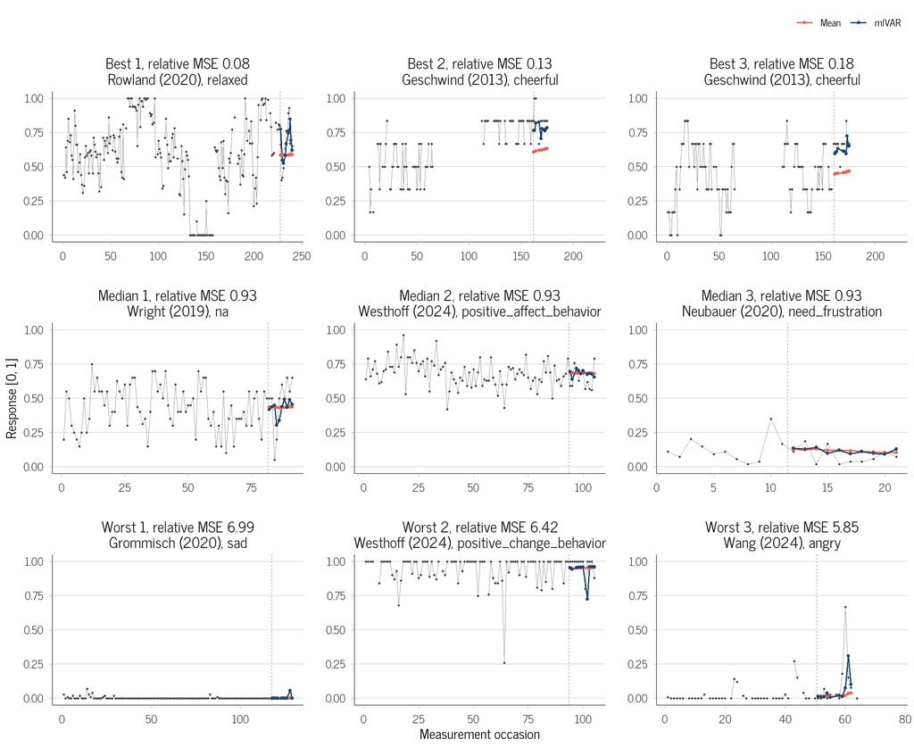

Figure 9: Observed series and OOS predictions for the persons with the lowest, median and highest MSE of mlVAR relative to the mean model. One typical item per person. The dashed line marks the first OOS origin.

```r
# person-level relative MSE of mlVAR, lower is better
person_rel <- combined |>
  filter(set == "oos", model == "ml_var", is.finite(rel_mse)) |>
  select(dataset_id, first_author, year, id, rmse, rel_mse) |>
  arrange(rel_mse, dataset_id, id)

median_rel <- median(person_rel$rel_mse)
selected <- bind_rows(
  slice_min(person_rel, rel_mse, n = 3, with_ties = FALSE) |> mutate(group = "Best"),
  slice_min(person_rel, abs(log(rel_mse / median_rel)), n = 3, with_ties = FALSE) |>
    mutate(group = "Median"),
  slice_max(person_rel, rel_mse, n = 3, with_ties = FALSE) |> mutate(group = "Worst")
) |>
  mutate(rank = row_number(), .by = group)

# item-level MSE ratio of mlVAR vs. the mean model
item_rel <- features$item_error |>
  filter(model %in% c("mean", "ml_var")) |>
  select(dataset_id, id, variable, model, mse) |>
  pivot_wider(names_from = model, values_from = mse, names_prefix = "mse_") |>
  filter(mse_mean > 0, mse_ml_var > 0) |>
  mutate(item_rel = mse_ml_var / mse_mean)

# per person, the item whose ratio is closest to that person's median item ratio (on the log axis)
gallery_items <- selected |>
  select(dataset_id, first_author, year, id, rel_mse, group, rank) |>
  inner_join(item_rel, by = c("dataset_id", "id")) |>
  slice_min(abs(log(item_rel / median(item_rel))), n = 1, with_ties = FALSE,
            by = c(dataset_id, id)) |>
  mutate(group = factor(group, levels = c("Best", "Median", "Worst"))) |>
  arrange(group, rank) |>
  mutate(panel = sprintf("%s %d, relative MSE %.2f\n%s (%s), %s",
                         group, rank, rel_mse, first_author, year, variable),
         panel = factor(panel, levels = panel))

gallery_keys <- select(gallery_items, dataset_id, id, variable, panel)

gallery_series <- features$series |>
  inner_join(gallery_keys, by = c("dataset_id", "id", "variable"))

gallery_preds <- features$oos |>
  filter(model %in% c("mean", "ml_var")) |>
  inner_join(gallery_keys, by = c("dataset_id", "id", "variable")) |>
  mutate(model = factor(model, levels = c("mean", "ml_var"), labels = c("Mean", "mlVAR")))

first_origin <- summarise(gallery_preds, t0 = min(t), .by = panel)

ggplot(gallery_series, aes(x = t, y = y)) +
  geom_vline(data = first_origin, aes(xintercept = t0 - 0.5),
             linetype = "dashed", colour = "grey50", linewidth = 0.3) +
  geom_line(colour = "grey60", linewidth = 0.3) +
  geom_point(colour = "grey30", size = 0.5) +
  geom_line(data = gallery_preds, aes(y = yhat, colour = model), linewidth = 0.6) +
  geom_point(data = gallery_preds, aes(y = yhat, colour = model), size = 1) +
  scale_colour_manual(values = model_palette, name = NULL) +
  ggh4x::facet_wrap2(~ panel, ncol = 3, scales = "free_x", axes = "all") +
  coord_cartesian(ylim = c(0, 1)) +
  labs(x = "Measurement occasion", y = "Response [0, 1]") +
  theme_bs(base_size = 11)
```

## 3.9 Absolute vs. relative performance

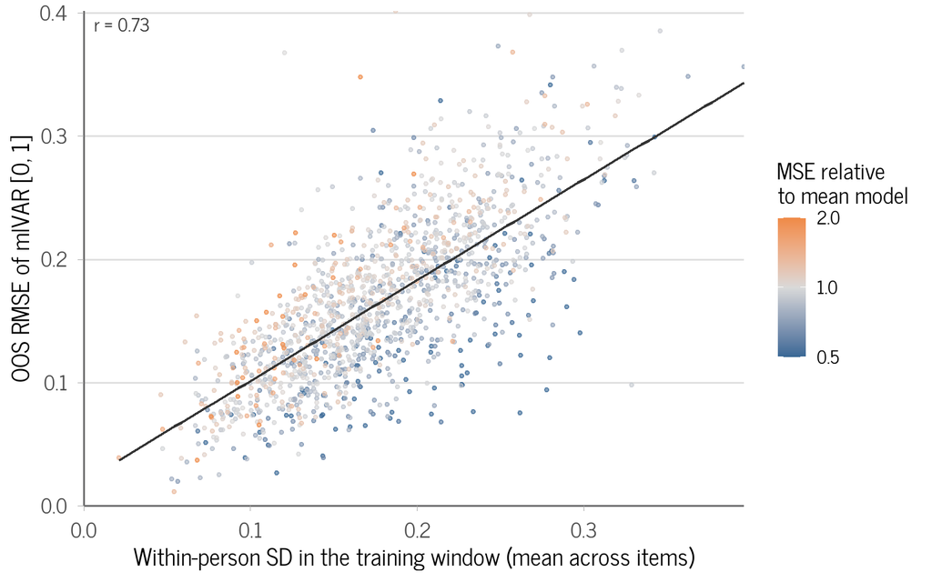

Figure 10: Person-level OOS RMSE of mlVAR by within-person variability in the training window, coloured by MSE relative to the mean model.

```r
abs_rel <- person_rel |>
  left_join(select(features$person, dataset_id, id, sd_train_mean), by = c("dataset_id", "id"))

stopifnot(!anyNA(abs_rel$sd_train_mean))

r_sd_rmse <- cor(abs_rel$sd_train_mean, abs_rel$rmse)

ggplot(abs_rel, aes(x = sd_train_mean, y = rmse, colour = rel_mse)) +
  geom_point(alpha = 0.6, size = 1) +
  geom_smooth(method = "lm", formula = y ~ x, se = FALSE, colour = "grey20",
              linewidth = 0.8) +
  annotate("text", x = -Inf, y = Inf, label = sprintf("r = %.2f", r_sd_rmse),
           hjust = -0.2, vjust = 1.5, size = 4, colour = "grey20") +
  # log colour scale centred on 1 (same error as the mean model)
  scale_colour_gradient2(low = component_palette[["Autoregression"]], mid = "grey85",
                         high = component_palette[["Cross-dynamics"]], midpoint = 1,
                         transform = "log10", limits = c(0.5, 2), oob = scales::oob_squish,
                         breaks = c(0.5, 1, 2), name = "MSE relative\nto mean model") +
  coord_cartesian(xlim = c(0, NA), ylim = c(0, NA), expand = FALSE) +
  labs(x = "Within-person SD in the training window (mean across items)",
       y = "OOS RMSE of mlVAR [0, 1]") +
  theme_bs() +
  theme(legend.position = "right")
```

This strong correlation suggests that the absolute performance of mlVAR is largely determined by the within-person variability of the series.

## 3.10 Model selection by in-sample fit

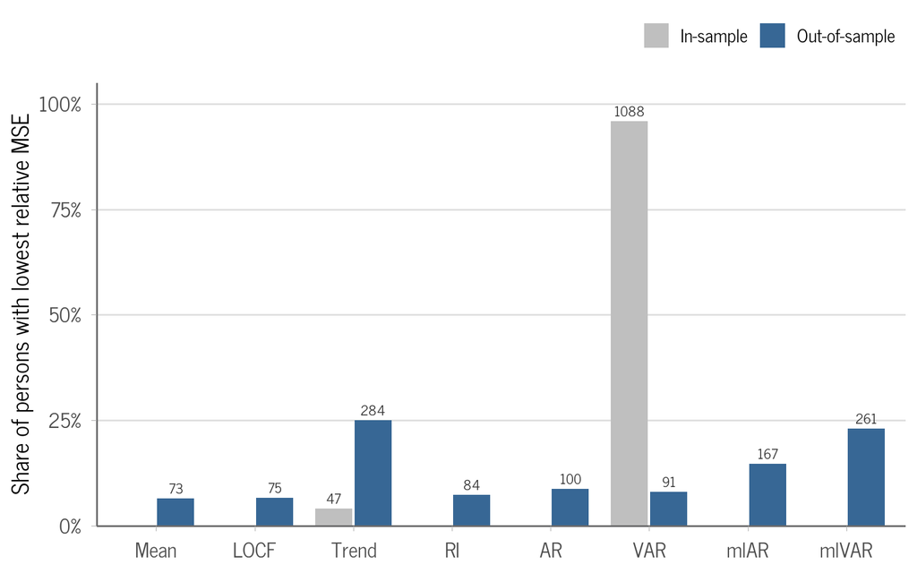

Figure 11: Share of persons for whom each model has the lowest in-sample and out-of-sample relative MSE. Numbers are counts of persons.

```r
best_model <- combined |>
  filter(set %in% c("in", "oos"), is.finite(rel_mse)) |>
  mutate(n_model_sets = n_distinct(model, set), .by = c(dataset_id, id)) |>
  # a person's best model is only comparable if all models have a defined relative MSE in both sets
  filter(n_model_sets == length(model_order) * 2) |>
  # for each person, select the model with the lowest relative MSE in each set
  slice_min(rel_mse, n = 1, with_ties = FALSE, by = c(dataset_id, id, set)) |>
  select(dataset_id, id, set, model) |>
  pivot_wider(names_from = set, values_from = model)

selection <- best_model |>
  pivot_longer(c(`in`, oos), names_to = "set", values_to = "model") |>
  count(set, model) |>
  complete(set, model = model_order, fill = list(n = 0)) |>
  mutate(share = n / sum(n), .by = set) |>
  mutate(model = factor(model, levels = model_order, labels = model_labels),
         set = factor(set, levels = c("in", "oos"), labels = c("In-sample", "Out-of-sample")))

ggplot(selection, aes(x = model, y = share, fill = set)) +
  geom_col(position = position_dodge(width = 0.8), width = 0.75) +
  geom_text(aes(label = if_else(n > 0, as.character(n), ""), y = share),
            position = position_dodge(width = 0.8), vjust = -0.5, size = 3, colour = "grey20") +
  scale_fill_manual(values = c("In-sample" = "grey75",
                               "Out-of-sample" = component_palette[["Autoregression"]]),
                    name = NULL) +
  scale_y_continuous(labels = scales::label_percent(), limits = c(0, 1.05), expand = c(0, 0)) +
  labs(x = NULL, y = "Share of persons with lowest relative MSE") +
  theme_bs()
```

# 4 Model-Based Estimates of Predictive Accuracy

## 4.1 M1 (Model using only model as predictor)

We estimated a log-normal meta-regression model with only the model as a predictor. We can now use the outputs of this model to create a forest plot-like visualization of the predictive accuracy of each model across datasets.

TODO I’m not sure if that is the best way to visualize this - the dataset specific effects might not really come through here.

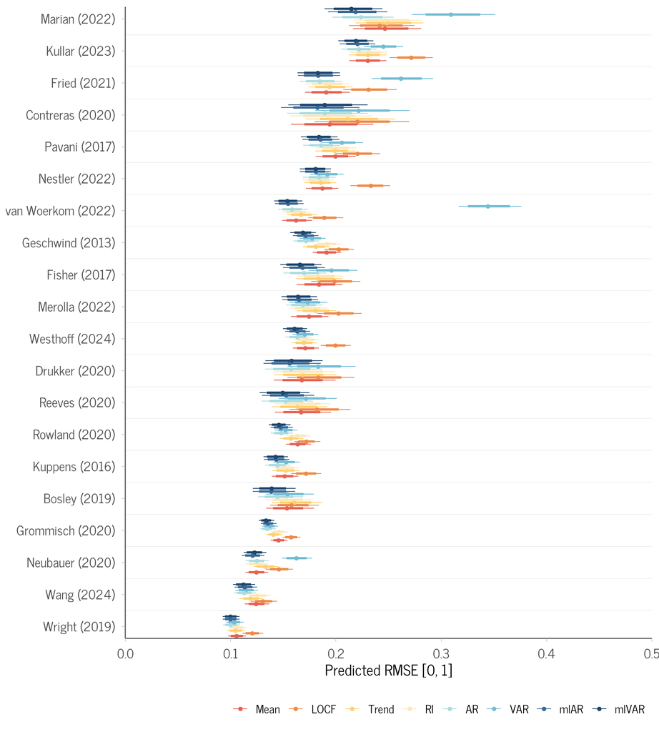

```r
fit_rmse_lognormal <- readRDS(here::here("output", "analysis", "fit_rmse_lognormal.rds"))

newdata <- expand.grid(
  model = levels(fit_rmse_lognormal$data$model),
  dataset_id = unique(fit_rmse_lognormal$data$dataset_id),
  unique_id = NA,
  stringsAsFactors = FALSE
)

preds <- newdata |>
  add_epred_draws(fit_rmse_lognormal, re_formula = ~ (1 | dataset_id) + (1 | dataset_id:model),
                  # for the dataset-level predictions, we do not include the person-level random effect
                  allow_new_levels = TRUE) |>
  ungroup() |>
  mutate(model = factor(model, levels = model_order, labels = model_labels))

preds <- preds |>
  left_join(dataset_meta |> select(dataset_id, first_author, year), by = "dataset_id") |>
  mutate(dataset_label = paste0(first_author, " (", year, ")"))

ggplot(preds, aes(x = .epred, y = reorder(dataset_label, .epred),
                  colour = model)) +
  stat_pointinterval(position = position_dodge(width = 0.7),
                     .width = c(0.80, 0.95),
                     point_size = 1.5, interval_size_range = c(0.4, 1.2)) +
  scale_colour_manual(values = model_palette) +
  coord_cartesian(xlim = c(0, 0.5), expand = FALSE) +
  labs(x = "Predicted RMSE [0, 1]", y = NULL, colour = NULL) +
  theme_bs() +
  theme(legend.position = "bottom",
        panel.grid.major.y = element_blank())+
  geom_hline(yintercept = seq(1.5, length(unique(preds$dataset_label)) - 0.5, 1),
           colour = "grey90", linewidth = 0.3) +
  guides(colour = guide_legend(nrow = 1, byrow = TRUE))
```